# Point Pattersn, Trajectories

Edzer Pebesma

1/17/2021

## Point Patterns

Some Resources:

- the [spatstat](https://cran.r-project.org/web/packages/spatstat/index.html) CRAN package; also one of the largest packages of CRAN (CRAN forced it to break up), and its author list is a who-is-who in the point process world.
- the spatstat book [Spatial Point Patterns: Methodology and Applications with R](http://spatstat.org/book.html), by Baddeley, Rubak and Turner (CRC; around 1000 pages)
- slides from the spatstat authors: https://spatstat.org/SSAI2017/slides/slides.pdf

### What is a point pattern?

Examples of point patterns include all kinds of “point-observable” phenomena (objects, or events)

- distribution of trees, cells, stars, cars, people, thunderstorms, lightning strikes, vulcano eruptions, plane crashes, disease cases, accidents, robberies, and so on.

A set of locations (two- or three-dimensional, but typically 2D) along with an observation window. Points - OK, but why an observation window?

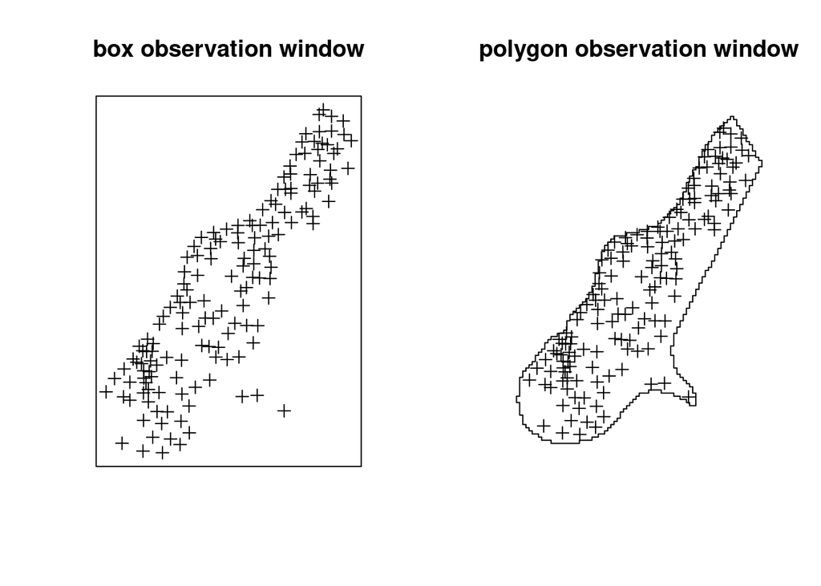

```r
library(sp)
data(meuse)
coordinates(meuse) = ~x+y
par(mfrow = c(1,2))
plot(meuse)
title("box observation window")
box()
data(meuse.area)
plot(meuse, xlim = range(meuse.area[,1]))
title("polygon observation window")
lines(meuse.area)
```

On the left, points are *not* homogeneously distributed over the (box) area. On the right, points are reasonably homogeneously distributed over the study area (polygon). Homogeneity is an important property of a point process.

The observation window *implies* that within this window, we observed all points. Outside the window, there may be more points, but that is not of interest.

The observation window may also be funny shaped: for (normal) cars, it is the street network: effectively a set of connected 1-D elements. Distances then also have to be computed through this network.

For point pattern data, the primary interest lies in *where* the points happen. Locations between the points are “empty”. In contrast, for geostatistical data, the interest lies in *what* is observed at these points (which values are measured) and what happens between these points (interpolation). Locations between the observed points are not “empty” but are “unobserved” (“NA”).

### Point patterns, point processes

Point patterns concerns what we have observed, i.e. properties of the world. The question is how we could describe this, i.e. what kind of mathematical model or *process* could cause an outcome like the one we observed. We use random processes for this. At least two important properties describe such processes:

- first order properties (‘means’): the intensity of the process, $\lambda(s)$ at location $s$. This leads to point processes being homogeneous or inhomogeneous: a homogeneous point process has a spatially constant intensity $\lambda(s) = \lambda$. For an inhomogeneous point process, intensity $\lambda(s)$ depends on location.
- second order properties (‘correlations’): the interaction between points: if $s_i$ has a point, is it more likely, less likely, or indifferent for $s_i+h$ (with small $h$) to *also* have a point? In case it is more likely we see clustered patterns, in case it is less likely we see repulsive patterns. Combinations are also possible (small clusters repulsing each other).

```r
library(spatstat)
```

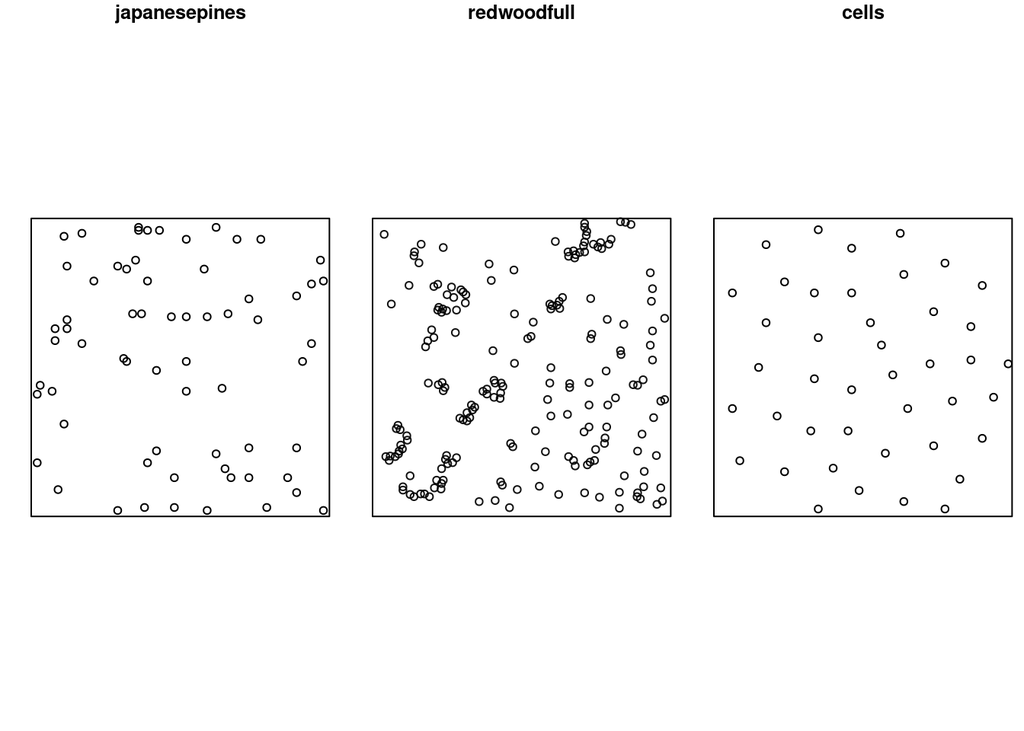

```r
data(japanesepines)
par(mfrow = c(1, 3), mar = c(1,1,1.2,0))
plot(japanesepines)
data(redwoodfull)
plot(redwoodfull)
data(cells)
plot(cells)
```

```r
data(swedishpines)
par(mfrow = c(1,2))
P <- swedishpines
plot(P)
Q <- quadratcount(P, nx=3, ny=3)
Q
```

```
##              x
## y             [0,32) [32,64) [64,96]
##   [66.7,100]       8       6       7
##   [33.3,66.7)      8      11       9
##   [0,33.3)         5       6      11
```

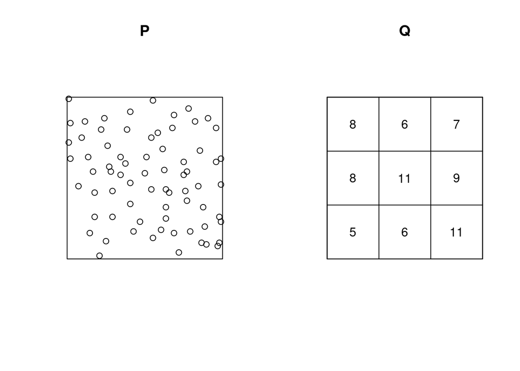

```r
plot(Q)
```

```r
quadrat.test(P, nx=3, ny=3)
```

```
##
##  Chi-squared test of CSR using quadrat counts
##
## data:  P
## X2 = 4.6761, df = 8, p-value = 0.4169
## alternative hypothesis: two.sided
##
## Quadrats: 3 by 3 grid of tiles
```

Computing densities:

1. replace each data point by a square of chocolate
2. melt chocolate with hair dryer
3. resulting landscape is a kernel smoothed estimate of intensity function

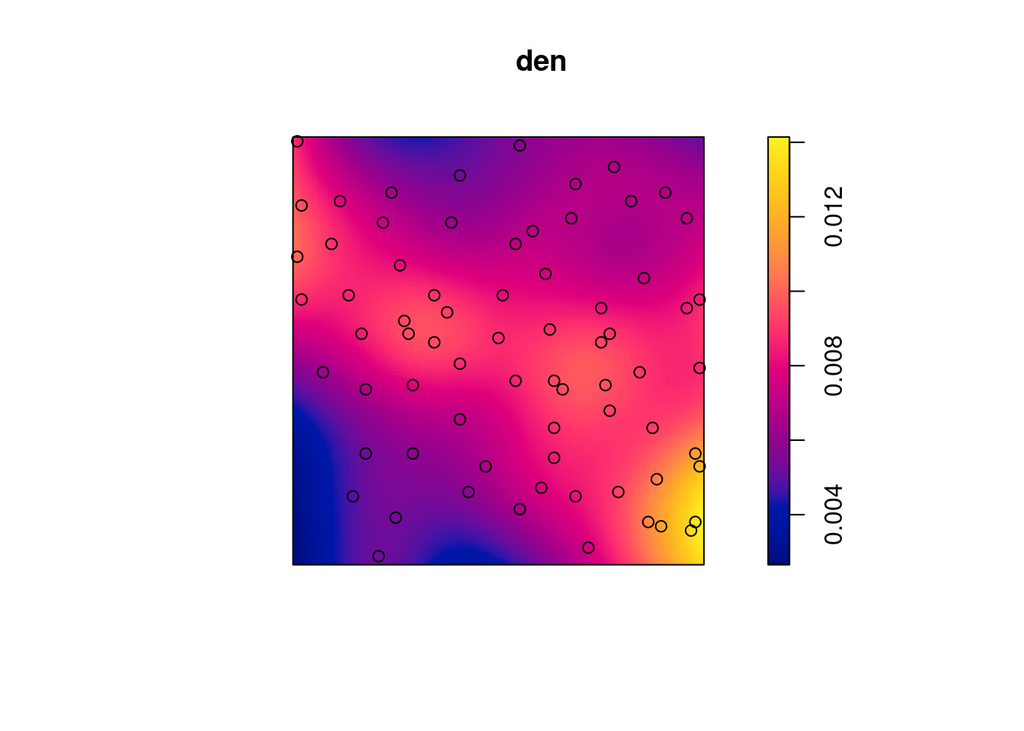

```r
den <- density(P)
plot(den)
plot(P, add=TRUE)
```

Bandwidth determines the amount of smoothing (the duration of melting):

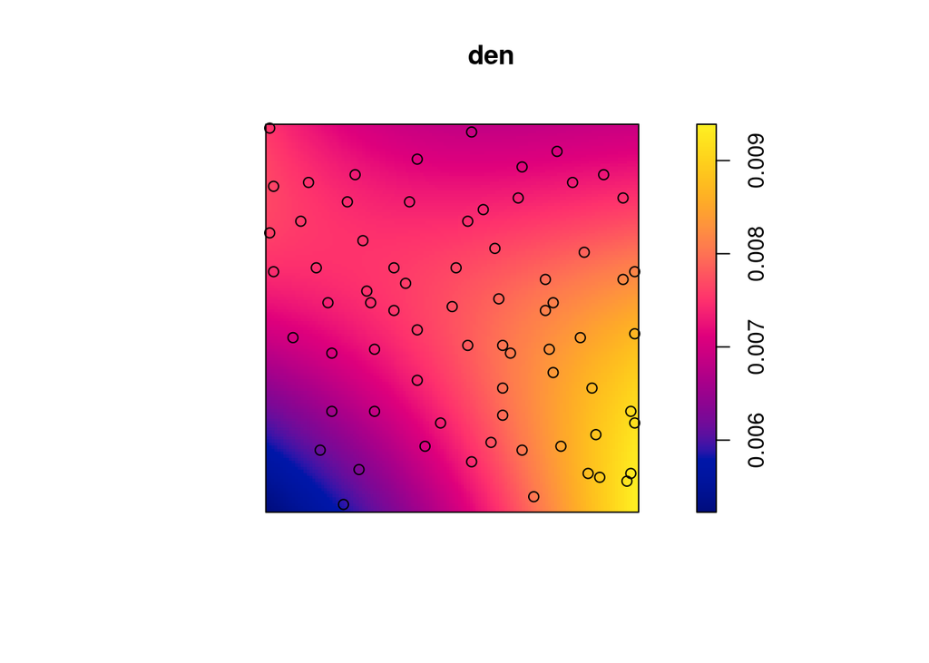

```r
den <- density(P, sigma=30)
plot(den)
plot(P, add=TRUE)
```

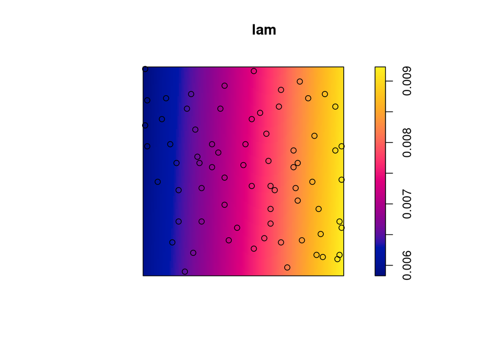

```r
fit <- ppm(P ~x+y)
lam <- predict(fit)
plot(lam)
plot(P, add=TRUE)
```

### Interactions

Look, for each point, at the distance to the nearest point, and compare this with what one would expect under CSR (completely spatial random, “pois”):

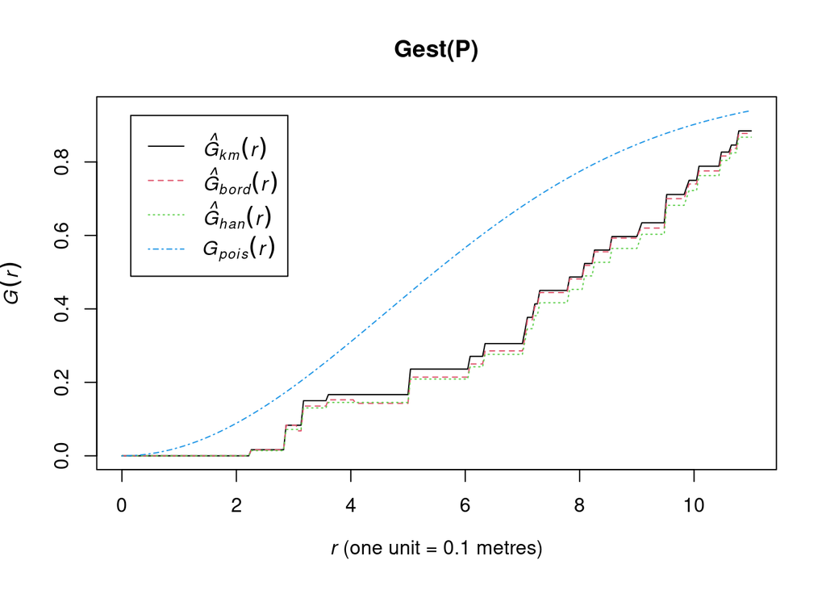

```r
plot(Gest(P))
```

```r
Penv <- envelope(P, fun=Gest, nrank=2, nsim=99)
```

```
## Generating 99 simulations of CSR  ...
## 1, 2, 3, 4, 5, 6, 7, 8, 9, 10, 11, 12, 13, 14, 15, 16, 17, 18, 19, 20, 21, 22, 23, 24, 25, 26, 27, 28, 29, 30, 31, 32, 33, 34, 35, 36, 37, 38, 39, 40,
## 41, 42, 43, 44, 45, 46, 47, 48, 49, 50, 51, 52, 53, 54, 55, 56, 57, 58, 59, 60, 61, 62, 63, 64, 65, 66, 67, 68, 69, 70, 71, 72, 73, 74, 75, 76, 77, 78, 79, 80,
## 81, 82, 83, 84, 85, 86, 87, 88, 89, 90, 91, 92, 93, 94, 95, 96, 97, 98,  99.
##
## Done.
```

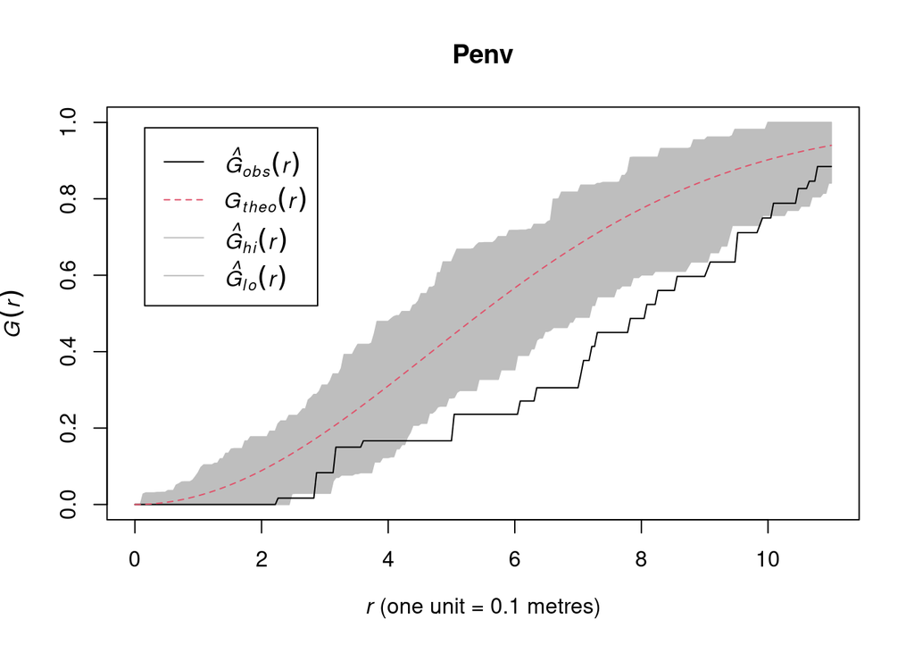

```r
plot(Penv)
```

For the earlier three examples:

```r
set.seed(120109)
envjap <- envelope(japanesepines, fun=Gest, nrank=2, nsim=99)
```

```
## Generating 99 simulations of CSR  ...
## 1, 2, 3, 4, 5, 6, 7, 8, 9, 10, 11, 12, 13, 14, 15, 16, 17, 18, 19, 20, 21, 22, 23, 24, 25, 26, 27, 28, 29, 30, 31, 32, 33, 34, 35, 36, 37, 38, 39, 40,
## 41, 42, 43, 44, 45, 46, 47, 48, 49, 50, 51, 52, 53, 54, 55, 56, 57, 58, 59, 60, 61, 62, 63, 64, 65, 66, 67, 68, 69, 70, 71, 72, 73, 74, 75, 76, 77, 78, 79, 80,
## 81, 82, 83, 84, 85, 86, 87, 88, 89, 90, 91, 92, 93, 94, 95, 96, 97, 98,  99.
##
## Done.
```

```r
envred <- envelope(redwoodfull, fun=Gest, nrank=2, nsim=99)
```

```
## Generating 99 simulations of CSR  ...
## 1, 2, 3, 4, 5, 6, 7, 8, 9, 10, 11, 12, 13, 14, 15, 16, 17, 18, 19, 20, 21, 22, 23, 24, 25, 26, 27, 28, 29, 30, 31, 32, 33, 34, 35, 36, 37, 38, 39, 40,
## 41, 42, 43, 44, 45, 46, 47, 48, 49, 50, 51, 52, 53, 54, 55, 56, 57, 58, 59, 60, 61, 62, 63, 64, 65, 66, 67, 68, 69, 70, 71, 72, 73, 74, 75, 76, 77, 78, 79, 80,
## 81, 82, 83, 84, 85, 86, 87, 88, 89, 90, 91, 92, 93, 94, 95, 96, 97, 98,  99.
##
## Done.
```

```r
envcells <- envelope(cells, fun=Gest, nrank=2, nsim=99)
```

```
## Generating 99 simulations of CSR  ...
## 1, 2, 3, 4, 5, 6, 7, 8, 9, 10, 11, 12, 13, 14, 15, 16, 17, 18, 19, 20, 21, 22, 23, 24, 25, 26, 27, 28, 29, 30, 31, 32, 33, 34, 35, 36, 37, 38, 39, 40,
## 41, 42, 43, 44, 45, 46, 47, 48, 49, 50, 51, 52, 53, 54, 55, 56, 57, 58, 59, 60, 61, 62, 63, 64, 65, 66, 67, 68, 69, 70, 71, 72, 73, 74, 75, 76, 77, 78, 79, 80,
## 81, 82, 83, 84, 85, 86, 87, 88, 89, 90, 91, 92, 93, 94, 95, 96, 97, 98,  99.
##
## Done.
```

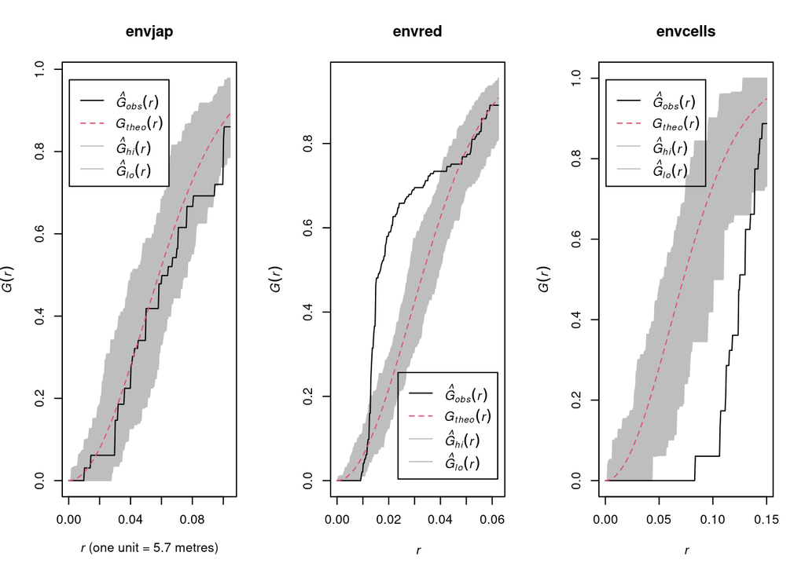

```r
par(mfrow = c(1,3))
plot(envjap)
plot(envred)
plot(envcells)
```

### Marked point patterns

Marked point patterns have properties associated with each point (e.g., tree species, tree size, age of a person). Analysis may focus on the marks, and/or the interaction of marks and locations (do species A and B have different preferences? Do they then to attract or repulse each other? Do large trees occur more often solitary?)

## Spatiotemporal Point Processes

Spatio-temporal point patterns are observed over space-time: each point has a spatial location and a moment of observation. As this concerns points, the moment should not be a (long) period; if it concerns periods, the start of the period can be taken (e.g. by disease cases, when outbreak / infection rate is of interest).

For a spatiotemporal point process, the object (event) is thought of as not moving. If it moves, we call it a trajectory.

## Trajectories

Trajectories are formed by moving objects or events: people, cars, thunderstorms, planes, birds, air particles, and so on. Laws of physics determine that an object has one and only one location for each point in time of its existence, and hence is a function

$$T \Rightarrow S$$

(or: $S = f(T)$).

*Observed* trajectories typically consist of *fixes*, an ordered sequence of $(T,S)$ time-location pairs, maximally one location per time step.

In adittion to fixes, there may be *attributes*, related to

- each fix, subsequent sets of fixes, and derived from the fixes (speed, direction, acceleration, transportation mode)
- each fix, and externally measured (temperature, air pressure, fuel consumption, any sensed property)
- each trajectory (the ID of the object moving)

Fixes may be dense (e.g., GPS fix every few seconds) or sparse (e.g., your bank card payments), and may be regular or irregularly distributed over time. Dense trajectories are often interpolated linearly, or even thinned before analysis. Linear interpolation is simple, but physically always unrealistic.

(Interpolated) movement can be free (birds, air particles, thunder storms, planes) or restricted (persons, cars, fish).

- (example Google timeline)

Analysis questions may involve:

- how can we reconstruct the hurricane path from 6-hr locations?
- where does bird species $x$ spend the winter?
- can persons A and B have met during day D? (alibi problem)
- can we predict traffic jams for time T, day Y?
- How should we drive and when will we arrive in location X (navigation)

[figure not shown]

```r
library(trajectories)
smth = function(x,y,xout,...) predict(smooth.spline(as.numeric(x), y), as.numeric(xout))
data(storms)
plot(storms, type = 'p')
```

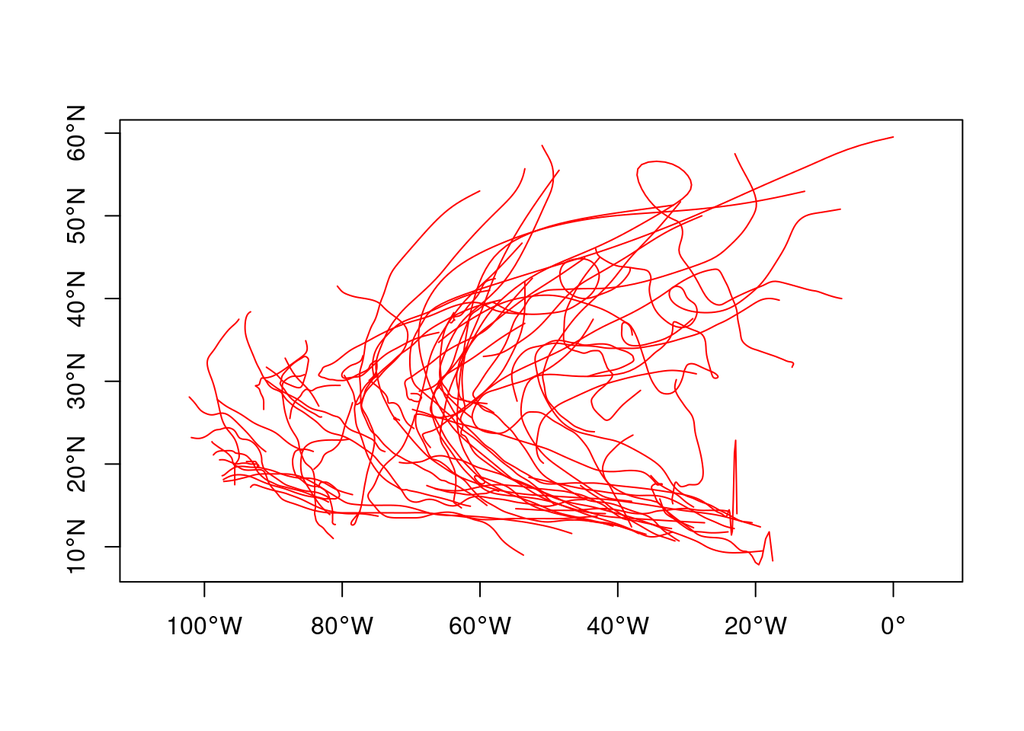

```r
suppressWarnings(storms.smooth <- approxTracksCollection(storms, FUN = smth, n = 200))
plot(storms.smooth, col = 'red')
```

[output not shown]